# Pratical machine learning coursera

eric

2016年3月5日

# Final Project Report - Practical Machine Learning Course

## Link the file directly

```r
library(caret)
library(rpart)
library(data.table)
```

```r
url="https://d396qusza40orc.cloudfront.net/predmachlearn/pml-training.csv"
url2="https://d396qusza40orc.cloudfront.net/predmachlearn/pml-testing.csv"
```

```r
training.data=read.csv(url,header = TRUE)
test.data=read.csv(url2,header = TRUE)
```

Depending on the background,we want to use other covariate(especially the exercise’ quantity and qualitative data)to predict the performance not to depend on person or times ,etc.And I also check whether the anticipant are the same or not,preventing the bias that will made.

## Exploratory

just to see the person are same or not

```r
str(training.data)
```

```
## 'data.frame':    19622 obs. of  160 variables:
##  $ X                       : int  1 2 3 4 5 6 7 8 9 10 ...
##  $ user_name               : Factor w/ 6 levels "adelmo","carlitos",..: 2 2 2 2 2 2 2 2 2 2 ...
##  $ raw_timestamp_part_1    : int  1323084231 1323084231 1323084231 1323084232 1323084232 1323084232 1323084232 1323084232 1323084232 1323084232 ...
##  $ raw_timestamp_part_2    : int  788290 808298 820366 120339 196328 304277 368296 440390 484323 484434 ...
##  $ cvtd_timestamp          : Factor w/ 20 levels "02/12/2011 13:32",..: 9 9 9 9 9 9 9 9 9 9 ...
##  $ new_window              : Factor w/ 2 levels "no","yes": 1 1 1 1 1 1 1 1 1 1 ...
##  $ num_window              : int  11 11 11 12 12 12 12 12 12 12 ...
##  $ roll_belt               : num  1.41 1.41 1.42 1.48 1.48 1.45 1.42 1.42 1.43 1.45 ...
##  $ pitch_belt              : num  8.07 8.07 8.07 8.05 8.07 8.06 8.09 8.13 8.16 8.17 ...
##  $ yaw_belt                : num  -94.4 -94.4 -94.4 -94.4 -94.4 -94.4 -94.4 -94.4 -94.4 -94.4 ...
##  $ total_accel_belt        : int  3 3 3 3 3 3 3 3 3 3 ...
##  $ kurtosis_roll_belt      : Factor w/ 397 levels "","-0.016850",..: 1 1 1 1 1 1 1 1 1 1 ...
##  $ kurtosis_picth_belt     : Factor w/ 317 levels "","-0.021887",..: 1 1 1 1 1 1 1 1 1 1 ...
##  $ kurtosis_yaw_belt       : Factor w/ 2 levels "","#DIV/0!": 1 1 1 1 1 1 1 1 1 1 ...
```

[output cut: 86 more lines]

We can see it contains a lot of NA

```r
levels(training.data$user_name)
```

```
## [1] "adelmo"   "carlitos" "charles"  "eurico"   "jeremy"   "pedro"
```

```r
levels(test.data$user_name)
```

```
## [1] "adelmo"   "carlitos" "charles"  "eurico"   "jeremy"   "pedro"
```

## Cleaning data

clean out the other unuseful variate

```r
training.data=training.data[,-(1:5)]
test.data=test.data[,-(1:5)]
```

clean the NAs that over the 0.8 of observation

```r
training.data=training.data[!colSums(is.na(training.data))>nrow(training.data)*0.8]
test.data=test.data[!colSums(is.na(test.data))>nrow(test.data)*0.8]
```

Find the near zero var and clean it.

```r
head(nearZeroVar(training.data, saveMetrics=TRUE))
```

```
##                  freqRatio percentUnique zeroVar   nzv
## new_window       47.330049    0.01019264   FALSE  TRUE
## num_window        1.000000    4.37264295   FALSE FALSE
## roll_belt         1.101904    6.77810621   FALSE FALSE
## pitch_belt        1.036082    9.37722964   FALSE FALSE
## yaw_belt          1.058480    9.97349913   FALSE FALSE
## total_accel_belt  1.063160    0.14779329   FALSE FALSE
```

```r
head(nearZeroVar(test.data, saveMetrics=TRUE))
```

```
##                  freqRatio percentUnique zeroVar   nzv
## new_window             0.0             5    TRUE  TRUE
## num_window             1.0           100   FALSE FALSE
## roll_belt              1.0            90   FALSE FALSE
## pitch_belt             1.0           100   FALSE FALSE
## yaw_belt               1.0            90   FALSE FALSE
## total_accel_belt       1.2            45   FALSE FALSE
```

```r
training.nzv=training.data[!nearZeroVar(training.data, saveMetrics=TRUE)$nzv==TRUE]
test.nzv=test.data[!nearZeroVar(test.data, saveMetrics=TRUE)$nzv==TRUE]
dim(training.nzv)
```

```
## [1] 19622    54
```

```r
dim(test.nzv)
```

```
## [1] 20 54
```

check out if the lastest variate is the same or not

```r
lookifthesame=ifelse(colnames(test.nzv)==colnames(training.nzv),"T","F")
lookifthesame
```

```
##  [1] "T" "T" "T" "T" "T" "T" "T" "T" "T" "T" "T" "T" "T" "T" "T" "T" "T"
## [18] "T" "T" "T" "T" "T" "T" "T" "T" "T" "T" "T" "T" "T" "T" "T" "T" "T"
## [35] "T" "T" "T" "T" "T" "T" "T" "T" "T" "T" "T" "T" "T" "T" "T" "T" "T"
## [52] "T" "T" "F"
```

Only the last one becasue the last one is the column we need to answer the predict result.

## Dataspliting

Because the test data is really small and we don’t know the result(out of box).so I need to do the cross validation to find the best accurary also reduce the rate of overfitting.

Split the training data into 0.9 subtraining and 0.1 subtesting ,after that I split the subtraining to 10 cross validation .Finally the output is **0.81 of subtraing each Chunk** **(All depend by the training data,and I only use the subtraining set to train the model.Finally use the subtesting set to test the out of sample error).**

```r
library(doMC)
registerDoMC(cores=4) ##make it faster by increasing thread
set.seed(1234)
trainIndex=createDataPartition(y=training.nzv$classe,p=0.9,list=FALSE)
subtraining=training.nzv[trainIndex,]
subtesting=training.nzv[-trainIndex,]
set.seed(1234)
flods=createFolds(y=subtraining$classe,list=TRUE,k=10,returnTrain=TRUE)
summary(flods)
```

```
##        Length Class  Mode
## Fold01 15895  -none- numeric
## Fold02 15895  -none- numeric
## Fold03 15896  -none- numeric
## Fold04 15896  -none- numeric
## Fold05 15897  -none- numeric
## Fold06 15895  -none- numeric
## Fold07 15896  -none- numeric
## Fold08 15897  -none- numeric
## Fold09 15896  -none- numeric
## Fold10 15895  -none- numeric
```

## Modeling

use the trainControl to set the parameter

```r
control <- trainControl(method = "cv", number = 10)
```

```r
registerDoMC(cores=4)
set.seed(1234)
modfit.rp1=train(classe~.,method="rpart",trControl=control ,data=subtraining)
predrp1=predict(modfit.rp1,subtraining)
confusionMatrix(predrp1,subtraining$classe)$overall
```

```
##       Accuracy          Kappa  AccuracyLower  AccuracyUpper   AccuracyNull
##      0.4966029      0.3420904      0.4892019      0.5040050      0.2843393
## AccuracyPValue  McnemarPValue
##      0.0000000            NaN
```

The accuracy is really bad,I add some preProces parameter to see if it perform better

```r
registerDoMC(cores=4)
set.seed(1234)
modfit.rp2=train(classe~.,method="rpart",preProcess=c("scale","center"),trControl=control ,data=subtraining)
predrp2=predict(modfit.rp1,subtraining)
confusionMatrix(predrp2,subtraining$classe)
```

```
## Confusion Matrix and Statistics
##
##           Reference
## Prediction    A    B    C    D    E
##          A 4574 1414 1426 1304  472
##          B   70 1171   99  501  431
##          C  365  833 1555 1090  873
##          D    0    0    0    0    0
##          E   13    0    0    0 1471
##
## Overall Statistics
##
##                Accuracy : 0.4966
##                  95% CI : (0.4892, 0.504)
##     No Information Rate : 0.2843
##     P-Value [Acc > NIR] : < 2.2e-16
##
##                   Kappa : 0.3421
##  Mcnemar's Test P-Value : NA
##
## Statistics by Class:
##
##                      Class: A Class: B Class: C Class: D Class: E
## Sensitivity            0.9108   0.3426  0.50487   0.0000  0.45303
## Specificity            0.6348   0.9227  0.78323   1.0000  0.99910
## Pos Pred Value         0.4977   0.5154  0.32973      NaN  0.99124
## Neg Pred Value         0.9471   0.8540  0.88220   0.8361  0.89022
## Prevalence             0.2843   0.1935  0.17439   0.1639  0.18384
## Detection Rate         0.2590   0.0663  0.08804   0.0000  0.08329
## Detection Prevalence   0.5203   0.1286  0.26701   0.0000  0.08402
## Balanced Accuracy      0.7728   0.6327  0.64405   0.5000  0.72607
```

seem the rpart’s performance is still not good,so I use gbm to test

```r
registerDoMC(cores=4)
set.seed(1234)
modfit.gbm=train(classe~.,method="gbm",trControl=control ,data=subtraining,verbose=FALSE)
predgbm=predict(modfit.gbm,subtraining)
confusionMatrix(predgbm,subtraining$classe)
```

```
## Confusion Matrix and Statistics
##
##           Reference
## Prediction    A    B    C    D    E
##          A 5017   20    0    2    0
##          B    5 3381   24    5    6
##          C    0   17 3052   25    5
##          D    0    0    3 2862   16
##          E    0    0    1    1 3220
##
## Overall Statistics
##
##                Accuracy : 0.9926
##                  95% CI : (0.9913, 0.9938)
##     No Information Rate : 0.2843
##     P-Value [Acc > NIR] : < 2.2e-16
##
##                   Kappa : 0.9907
##  Mcnemar's Test P-Value : NA
##
## Statistics by Class:
##
##                      Class: A Class: B Class: C Class: D Class: E
## Sensitivity            0.9990   0.9892   0.9909   0.9886   0.9917
## Specificity            0.9983   0.9972   0.9968   0.9987   0.9999
## Pos Pred Value         0.9956   0.9883   0.9848   0.9934   0.9994
## Neg Pred Value         0.9996   0.9974   0.9981   0.9978   0.9981
## Prevalence             0.2843   0.1935   0.1744   0.1639   0.1838
## Detection Rate         0.2841   0.1914   0.1728   0.1620   0.1823
## Detection Prevalence   0.2853   0.1937   0.1755   0.1631   0.1824
## Balanced Accuracy      0.9986   0.9932   0.9938   0.9937   0.9958
```

It’s really good.I use an other method to see it will be better or the same(I don’t use random forest because it’s really slow to my computer). I use svm to check out(No tuning the parameters.But if both the performances are equal I’ll try)

```r
registerDoMC(cores=4)
library(e1071)
set.seed(1234)
modfit.svm=svm(classe~.,trControl=control ,data=subtraining)
predsvm=predict(modfit.svm,subtraining)
confusionMatrix(predsvm,subtraining$classe)
```

```
## Confusion Matrix and Statistics
##
##           Reference
## Prediction    A    B    C    D    E
##          A 4995  181    5    2    0
##          B    0 3178   65    0    1
##          C   26   52 2987  246   41
##          D    0    2   20 2645   57
##          E    1    5    3    2 3148
##
## Overall Statistics
##
##                Accuracy : 0.9599
##                  95% CI : (0.9569, 0.9627)
##     No Information Rate : 0.2843
##     P-Value [Acc > NIR] : < 2.2e-16
##
##                   Kappa : 0.9492
##  Mcnemar's Test P-Value : < 2.2e-16
##
## Statistics by Class:
##
##                      Class: A Class: B Class: C Class: D Class: E
## Sensitivity            0.9946   0.9298   0.9698   0.9136   0.9695
## Specificity            0.9851   0.9954   0.9750   0.9947   0.9992
## Pos Pred Value         0.9637   0.9797   0.8911   0.9710   0.9965
## Neg Pred Value         0.9978   0.9834   0.9935   0.9833   0.9932
## Prevalence             0.2843   0.1935   0.1744   0.1639   0.1838
## Detection Rate         0.2828   0.1799   0.1691   0.1498   0.1782
## Detection Prevalence   0.2935   0.1837   0.1898   0.1542   0.1789
## Balanced Accuracy      0.9899   0.9626   0.9724   0.9541   0.9844
```

Gbm seem better than Svm.I use subtesting to check out of sample error of both model

```r
predgbm=predict(modfit.gbm,subtesting)
predsvm=predict(modfit.svm,subtesting)
confusionMatrix(predgbm,subtesting$classe)$overall
```

```
##       Accuracy          Kappa  AccuracyLower  AccuracyUpper   AccuracyNull
##      0.9852041      0.9812799      0.9788193      0.9900691      0.2846939
## AccuracyPValue  McnemarPValue
##      0.0000000            NaN
```

```r
confusionMatrix(predsvm,subtesting$classe)$overall
```

```
##       Accuracy          Kappa  AccuracyLower  AccuracyUpper   AccuracyNull
##      0.9474490      0.9334406      0.9366263      0.9569066      0.2846939
## AccuracyPValue  McnemarPValue
##      0.0000000            NaN
```

```r
oose.gbm <- 1 - as.numeric(confusionMatrix(subtesting$classe, predgbm)$overall[1])
oose.gbm
```

```
## [1] 0.01479592
```

```r
oose.svm <- 1 - as.numeric(confusionMatrix(subtesting$classe, predsvm)$overall[1])
oose.svm
```

```
## [1] 0.05255102
```

## Appendix:Variate importance and some conclusion

Then I look the variance important of gbm(firt ten)

```r
varimp=varImp(modfit.gbm, scale = FALSE)
```

Then we look closer

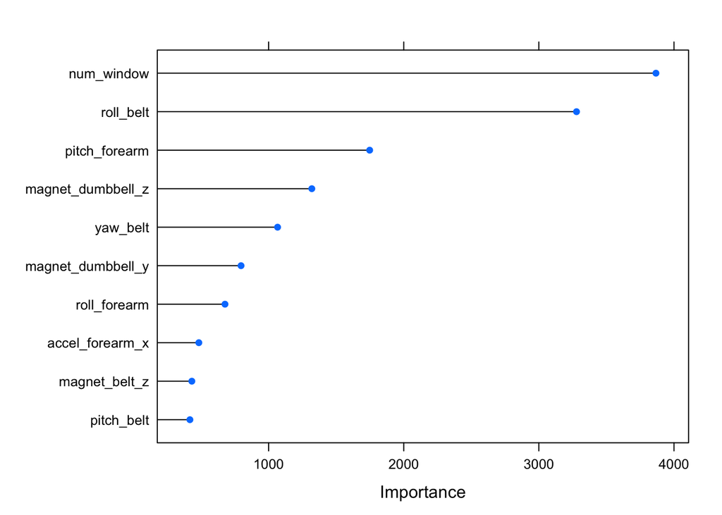

```r
plot(varimp,top=10)
```

We can see the more detail of variance importance

I also make some relation’s plot of two most important variates to find out some evidence if it can explain

*I found that take the the log of num_window can be easier to understand the data so I take the log of it.

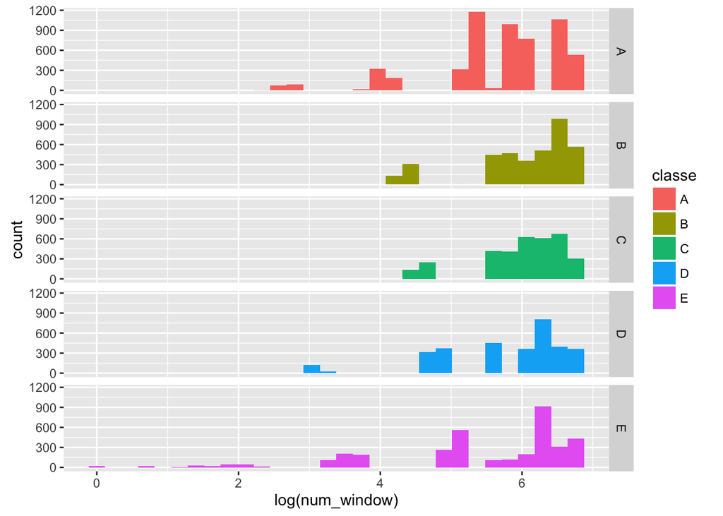

```r
ggplot(training.nzv,aes(x=log(num_window),fill=classe))+geom_histogram()+facet_grid(classe~.)
```

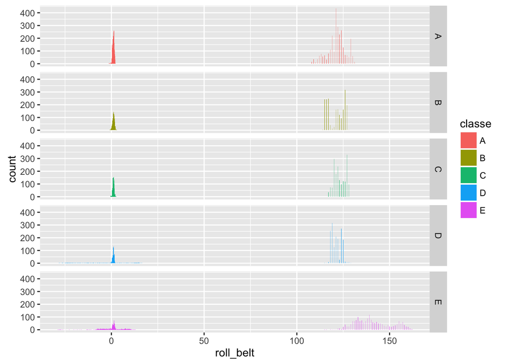

```r
ggplot(training.nzv,aes(x=roll_belt,fill=classe))+geom_histogram(binwidth = 0.1)+facet_grid(classe~.)
```

As you can see the distribution of two most important variate is different among classe(Not very significant but still can figure out,especially the E level compare to other levels).

## The Prediction quiz

```r
pred.reult=predict(modfit.gbm,test.nzv)
pred.reult
```

```
##  [1] B A B A A E D B A A B C B A E E A B B B
## Levels: A B C D E
```